# changepoint workshop

Stella Lee

6/6/2019

# What are Changepoints?

changepoint = instance in time where the statistical properties before and after this time point differ Mathematically speaking, for data $z_1, \ldots, z_n$, if a changepoint exists at $\tau$, then $z_1,\ldots,z_{\tau}$ differ from $z_{\tau+1},\ldots,z_n$ in some way. There are many different types of change.

### goal in changepoint analysis?

- occurance in change and where?
- difference between pre and post change data
- probability that a change has occured?
- how certain?

### Notation and concepts

Given the above definition of a changepoint, a change in mean has the following formulation:
$$z_t = \left\{ \begin{array}{lcl} \mu_1 & \mbox{if} & 1\leq t \leq \tau_1 \\
\mu_2 & \mbox{if} & \tau_1 < t \leq \tau_2 \\
\vdots & & \vdots \\
\mu_{k+1} & \mbox{if} & \tau_k < t \leq \tau_{k+1}=n \end{array} \right.$$
You can conceive of changes in all manner of parameters or in entire distributions. The following plots depict more complicated types of change. Can you guess where the changes are and what properties are changing?

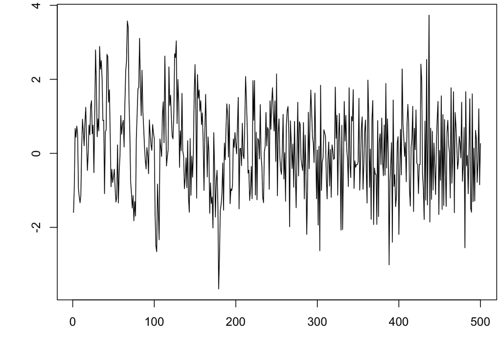

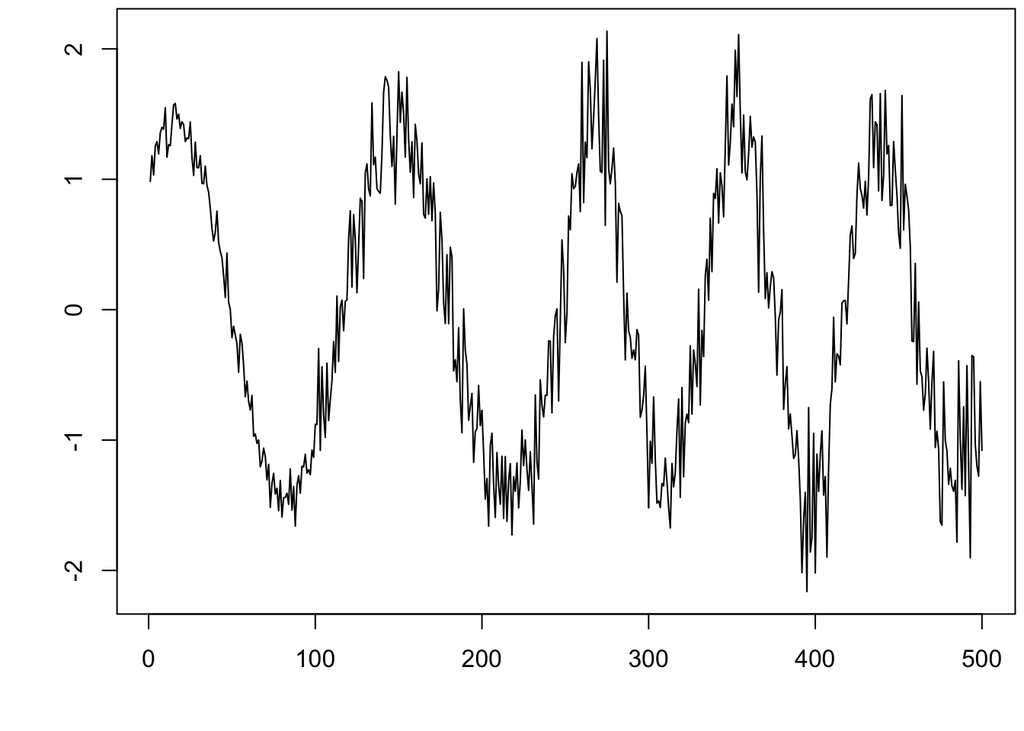

## Online vs Offline online - quick detection, arrives as datapoints (constant monitoring) offline - all data is received & processed one time

# Single Changepoint

find the number and position of poitns which the mean changes! 1. Likelihood Ratio Test:

## changepoint R package

cpt.mean - mean only changes cpt.val - variance only changes cpt.meanvar - mean and variance changes

The core functions cpt.mean, cpt.var, cpt.meanvar output an object of cpt class (unless class=FALSE is set). This is an S4 class containing all the information from the analysis including for example: the data (data.set), inputs set (pen.value,ncpts.max), outputs (cpts, param.est). The slots are accessed via their names e.g. cpts(x). There are also several standard methods available for the class e.g. plot, summary. Additional generic functions specific to changepoints are also available including: seg.len which returns the lengths of the segments between changepoints; ncpts which returns the number of changepoints identified.

## cpt.mean

cpt.mean(data, penalty=“MBIC”, pen.value=0, method=“AMOC”, Q=5, test.stat=“Normal”, class=TRUE, param.estimates=TRUE,minseglen=1) * data - vector or ts object * penalty - value used to ascertain what are material changes and what are not, options include: MBIC, SIC, BIC, AIC, Hannan-Quinn, Asymptotic, Manual. * pen.value - Type I error for Asymptotic, number or character to be evaluated for manual penalties. * method - AMOC, PELT, SegNeigh, BinSeg. * Q - max number of changes for SegNeigh or BinSeg. * test.stat - Test statistic, Normal or CUSUM. * class - return a cpt object or not. * param.estimates - return parameter estimates or not. * minseglen - minimum number of data points between changes.

```r
# Single Change in Mean
# simulate Normal distributed data with a single change in mean
set.seed(1)
m1 = c(rnorm(100,0,1), rnorm(100,5,1))
#plot(m1)
m1.amoc = cpt.mean(m1)
cpts(m1.amoc)
```

```
## [1] 100
```

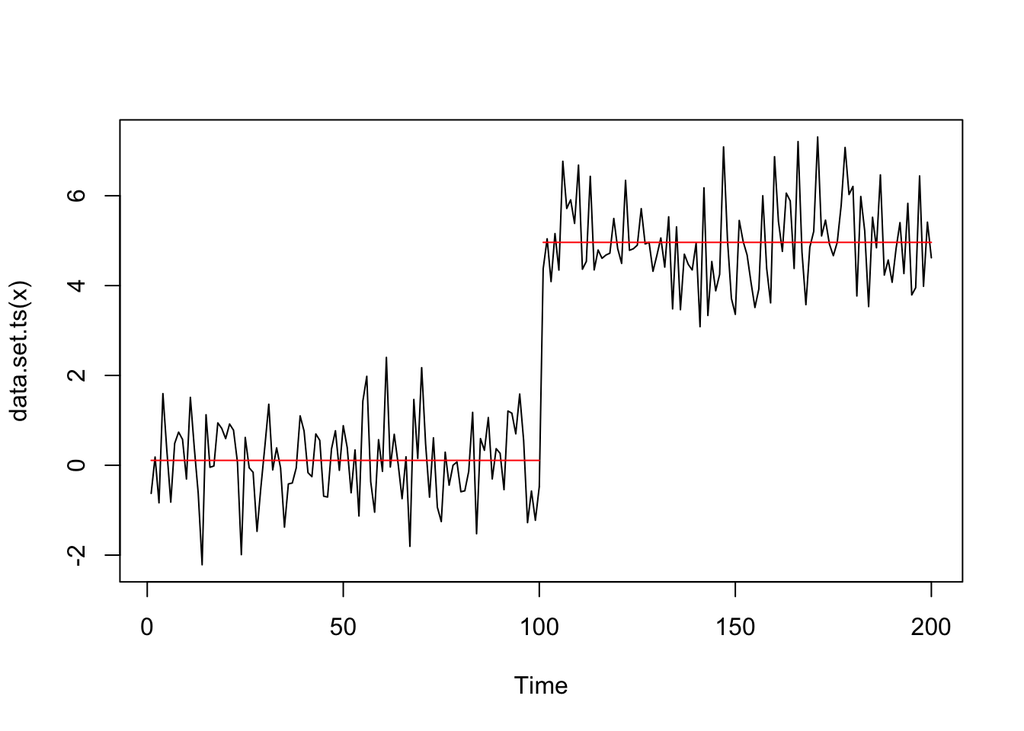

```r
# m1.cusum = cpt.mean(m1, pen.value = 1, penalty = 'Manual', test.stat = 'CUSUM')
# above line uses default values of a single change (method = 'AMOC') in a normal distribution (test.stat = "Normal") with the MBIC penalty (penalty = "MBIC")
plot(m1.amoc)
```

# Multiple Changepoints

We don’t know how many changepoints are there in the data and want to determine multiple changes

### Methods in the changepoint package

- For $n$ data points there are $2^{n-1}$ possible solutions
- If $k$ is known there are still $\binom{n-1}{k-1}$ solutions
- If $n=1000$ and $k=10$, $2.634096 \times 10^{21}$ solutions

methods to minimize over all possible values of $k$ and $\tau$:

- At Most One Change (`AMOC`) - only for single changepoint problems
- Binary Segmenation (`BinSeg`) (Scott and Knott (1974)) which is $\mathcal{O}(n\log n)$ in CPU time. *Approximate* but computationally **fast**
- Segment Neighbourhood (`SegNeigh`) (Auger and Lawrence (1989)) is $\mathcal{O}(Qn^2)$. *Slower* but **exact**
- Pruned Exact Linear Time (`PELT`) (Killick et al. (2012)) At worst $\mathcal{O}(n^2)$. For linear penalties $f(k)=k$, scaling changes, $\mathcal{O}(n)$. **Fast** and **exact**

(system.time() allows to check time)

## cpt.var

cpt.var(data, penalty, pen.value, know.mean=FALSE, mu=NA, method, Q, test.stat=“Normal”, class, param.estimates, minseglen=2)

The additional arguments are: know.mean - if known we don’t count it as an estimated parameter when calculating penalties. mu - Mean if known. test.stat - Normal or CSS (cumulative sums of squares) minseglen - Default is 2

```r
set.seed(1)
v1 = c(rnorm(100,0,1), rnorm(100,0,2), rnorm(100,0,10), rnorm(100,0,9))
v1.man = cpt.var(v1, method = 'PELT', penalty = "Manual", pen.value = "2*log(n)")
cpts(v1.man)
```

```
## [1] 102 200
```

```r
param.est(v1.man)
```

```
## $variance
## [1]  0.8007158  3.6933616 92.3876410
##
## $mean
## [1] 0.1986058
```

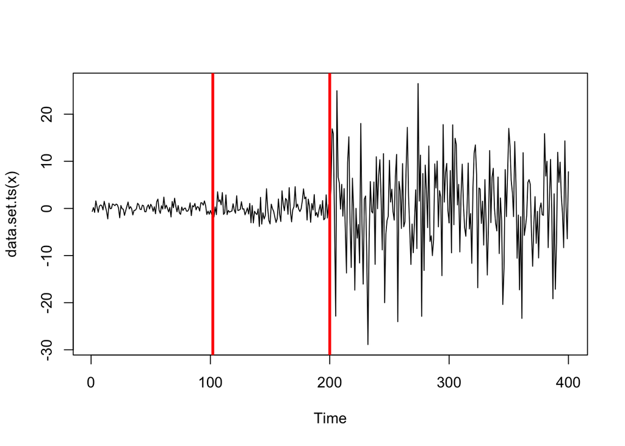

```r
plot(v1.man, cpt.width = 3)
```

## cpt.meanvar

cpt.meanvar(data, penalty, pen.value, method, Q, test.stat=“Normal”, class, param.estimates, shape=1,minseglen=2) Q is maximum number of changepoints that the algorithm will fine If the solution gives Q changepoints a warning –> increase Q (there mgiht more changes that missing currently) The different arguments here are: test.stat - choice of Normal, Gamma, Exponential, Poisson. shape - assumed shape parameter for Gamma. minseglen - minimum segment length of 2

```r
set.seed(1)
mv1=c(rexp(50,rate=1), rexp(50,5), rexp(50,2), rexp(50,7))
mv1.binseg=cpt.meanvar(mv1,test.stat='Exponential',method='BinSeg',Q=10,penalty="SIC")
cpts(mv1.binseg)
```

```
## [1]  50 100 150
```

```r
param.est(mv1.binseg)
```

```
## $rate
## [1] 1.016217 4.641184 2.235431 6.705612
```

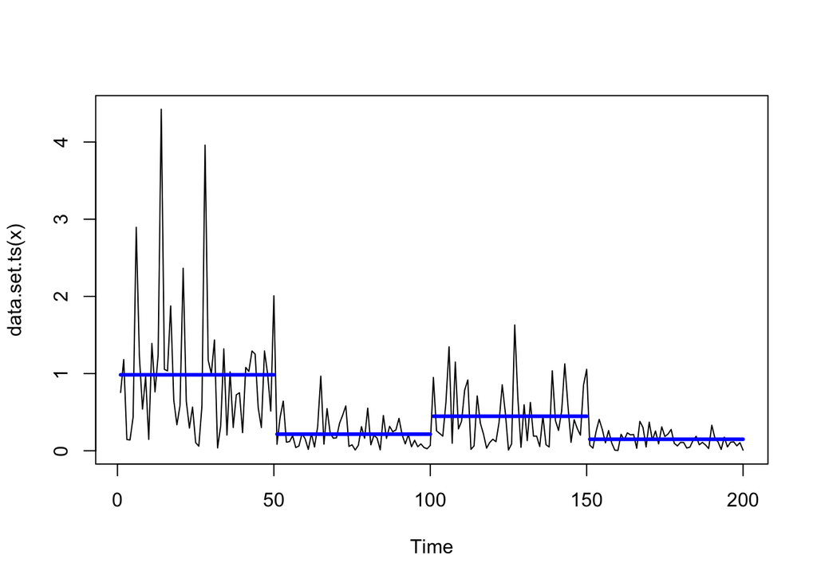

```r
plot(mv1.binseg,cpt.width=3,cpt.col='blue')
```

## How many changes?

penalty values? Enter CROPS: Changepoints for a range of penalties Using penalty=‘CROPS’ with method=‘PELT’ you can specify minimum and maximum penalty values and it returns all segmentations for any penalty between these values. These are computed in an efficient manner with a very small number of runs of the PELT algorithm. Once all the segmentations have been calculated we can then decide on the number of changepoints.

```r
v1.crops=cpt.var(v1,method="PELT",penalty="CROPS",pen.value=c(5,500))
```

```
## [1] "Maximum number of runs of algorithm = 10"
## [1] "Completed runs = 2"
## [1] "Completed runs = 3"
## [1] "Completed runs = 4"
## [1] "Completed runs = 5"
## [1] "Completed runs = 6"
## [1] "Completed runs = 8"
## [1] "Completed runs = 9"
```

```r
cpts.full(v1.crops) #cpts.full to get the range of segmentations
```

```
##      [,1] [,2] [,3] [,4] [,5] [,6] [,7] [,8]
## [1,]  102  114  133  201  206  213  375  379
## [2,]  102  114  133  201  206  375  379   NA
## [3,]  102  114  133  201  206   NA   NA   NA
## [4,]   96  133  201  206   NA   NA   NA   NA
## [5,]  102  201  206   NA   NA   NA   NA   NA
## [6,]  102  200   NA   NA   NA   NA   NA   NA
## [7,]  200   NA   NA   NA   NA   NA   NA   NA
## [8,]   NA   NA   NA   NA   NA   NA   NA   NA
```

```r
# when up to 8 changes are in the model we still don't have any changes around point 300
# retrieve the penalty boundary points:
pen.value.full(v1.crops)
```

```
## [1]   5.000000   5.431360   6.151053   6.270164   6.314013   6.526333
## [7]  54.317625 474.797364
```

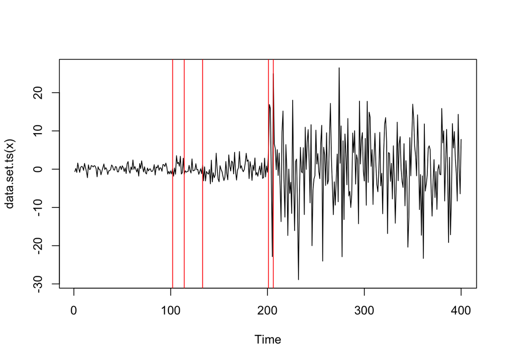

```r
# when using BinSeg or CROPS as a range of changepoints are given as output we can use additional arguement in the plot generic (allow us to select how many changes we want in the plot)
plot(v1.crops, ncpts=5)
```

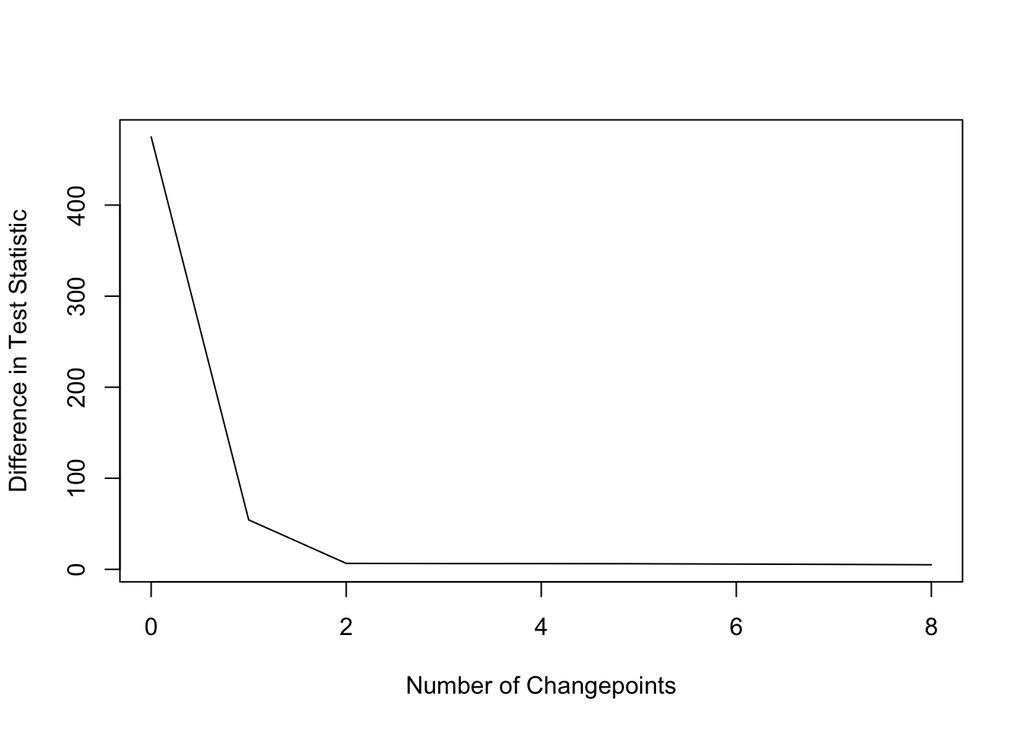

```r
# construct diagnostic plot:
plot(v1.crops, diagnostic = TRUE)
```

if true changepoint is added to the model, then the improvement in fit will be large once all the true changes have been added the false changes will not improve the fit much

## cpt.np

What if we want to find a general change in distribution? ==> changepoint.np package

cpt.np(data, penalty, pen.value, method, test.stat=“empirical_distribution”, class, minseglen=1, nquantiles=10)

Note that again the same underlying structure as cpt.mean is preserved. The additional arguments are: test.stat - choice of empirical_distribution minseglen - minimum segment length of 1 nquantiles - number of quantiles to use The empirical_distribution test statistic allows us to use quantiles of an empirical distrubtion function to identify changes in distribution. The method automatically choose which quantiles based on the number of quantiles (nquantiles). Obviously a large number of quantiles allows for more subtle changes in distribution to be detected but also required more computational time. Note that the quantiles are not evenly spread and are weighted more to the tails as this is where changes are often apparent.

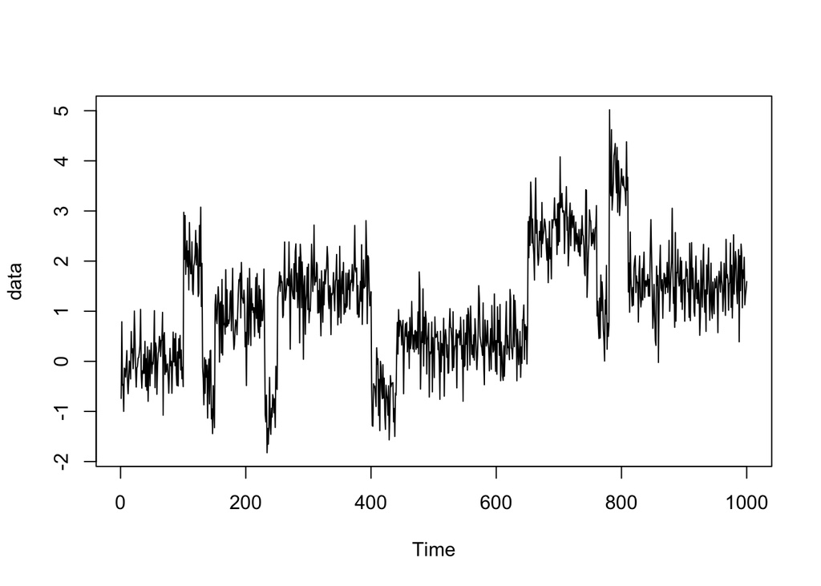

```r
set.seed(12)
J <- function(x){(1+sign(x))/2}
n <- 1000
tau <- c(0.1,0.13,0.15,0.23,0.25,0.4,0.44,0.65,0.76,0.78,0.81)*n
h <- c(2.01, -2.51, 1.51, -2.01, 2.51, -2.11, 1.05, 2.16,-1.56, 2.56, -2.11)
sigma <- 0.5
t <- seq(0,1,length.out = n)
data <- array()
for (i in 1:n){
   data[i] <- sum(h*J(n*t[i] - tau)) + (sigma * rnorm(1))
}
ts.plot(data)
```

```r
out <- cpt.np(data, method="PELT",minseglen=2, nquantiles =4*log(length(data)))
cpts(out)
```

```
##  [1] 100 130 150 230 250 400 440 650 760 780 810
```

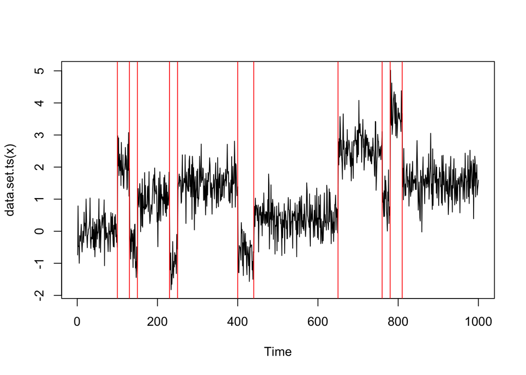

```r
plot(out)
```

# Checking Assumptions

## Segment check

## Residual check

## Task